# Math 189: Time Series I

# Time Series Data

- A *time series* is a dataset where the observations are recorded at discrete time intervals.
- We denote the obervation a time $t$ by $x_t$, and the random variable by $X_t$.
- We have times $t = 1, 2, \ldots, n$ for the *sample* $X_1, X_2, \ldots, X_n$.
- Time series data might not be i.i.d. (Independent and Identically Distributed)!

## Example: U.S. Population

- U.S. Population growth over the twentieth century.

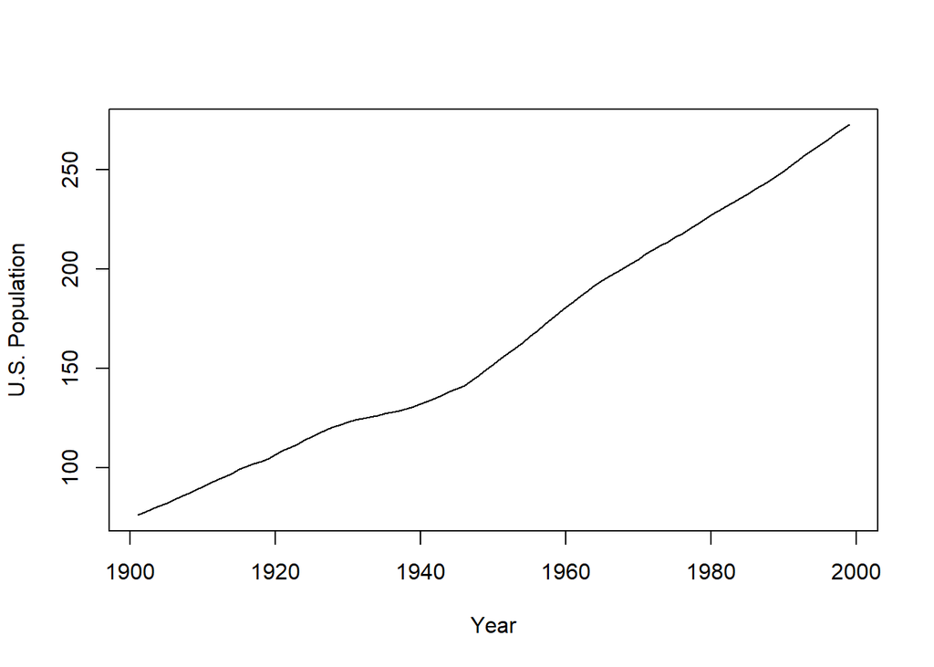

```r
pop <- read.table("USpop.dat")
pop <- ts(pop, start = 1901)
plot(pop*10e-7,xlab="Year",ylab="U.S. Population",lwd=1)
```

## Example: Urban World Population

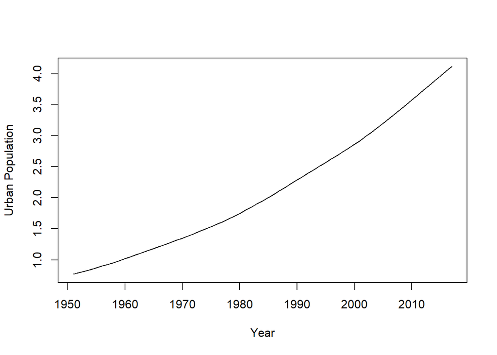

```r
urban <- read.table("urbanpop.dat")
urban <- ts(urban[67:1,], start = 1951)
plot(urban*1e-9,xlab="Year",ylab="Urban Population",lwd=1)
```

## Example: Non-Defense Capitalization

- Non-Defense Capitalization (New Orders) shows non-monotonic trend, and is more *noisy*.

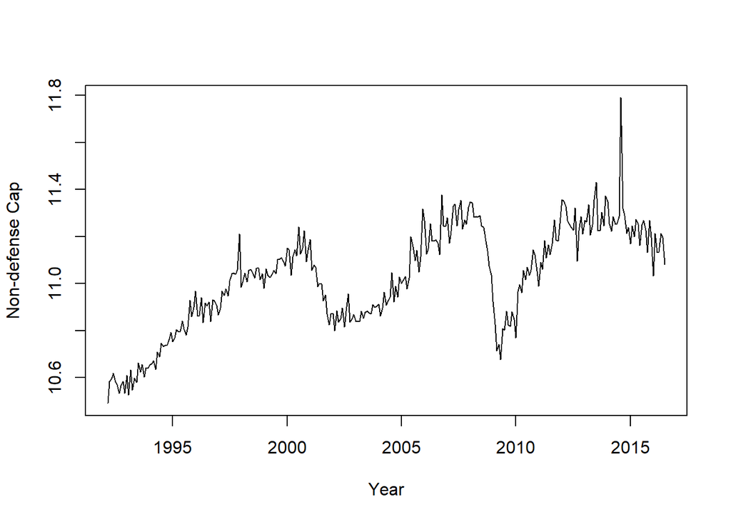

```r
ndc <- read.table("Nondefcap.dat")
ndc <- ts(ndc[,2],start=c(1992,3),frequency=12,names= "NewOrders")
plot(ndc,xlab="Year",ylab="Non-defense Cap")
```

## Serial Dependence and Forecasting

- Smoothness corresponds to high positive association (correlation) between adjacent variables.
- High association means forecasting (prediction of future values) is easier.

## Example: Dow Jones Industrial Average

- Dow Jones Industrial Average has trend, but is hard to forecast.

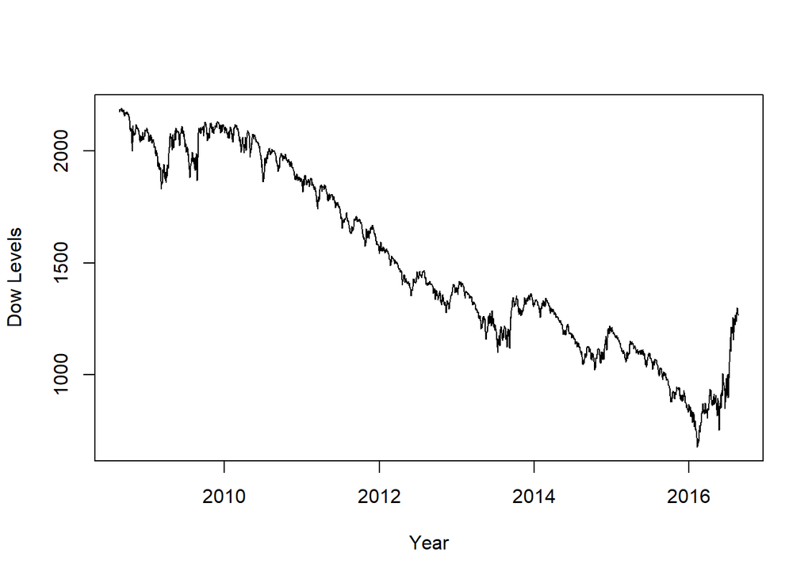

```r
dow <- read.table("dow.dat")
dow <- ts(dow,start=c(2008,164),frequency=252)
plot(dow,xlab="Year",ylab="Dow Levels")
```

- We can plot the log returns (consecutive difference of logged data), which shows how volatility is changing.

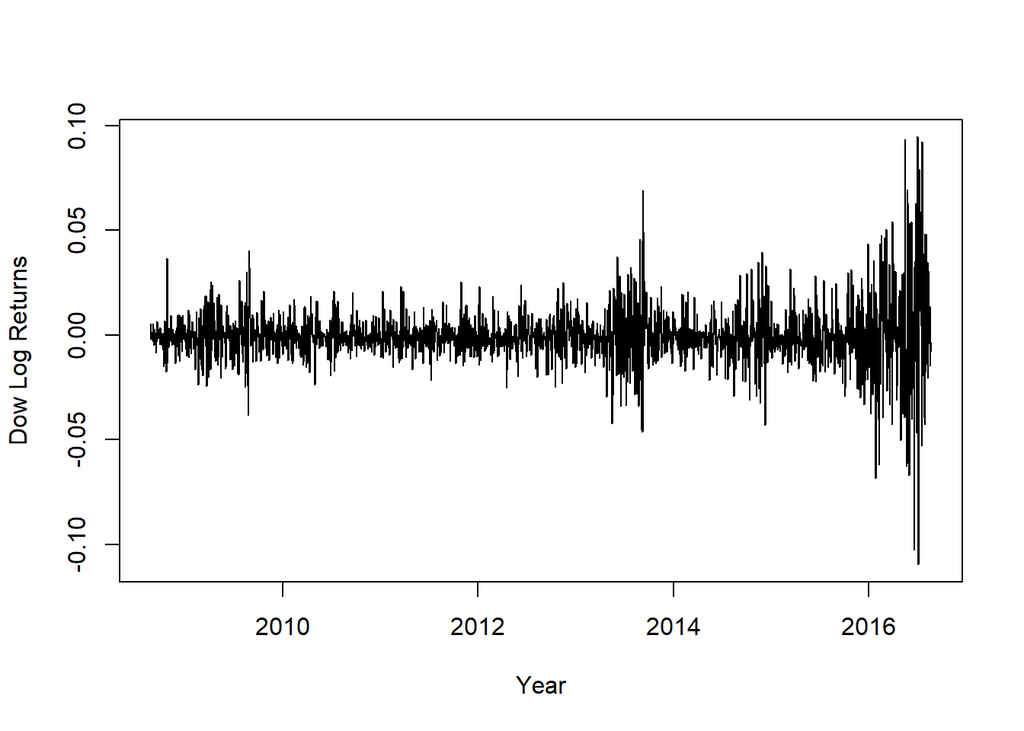

```r
dow.diff <- diff(log(dow[,1]))
plot(dow.diff,xlab="Year",ylab="Dow Log Returns")
```

# Cycles and Transforms

- High association can occur for non-adjacent random variables.
- For some fixed $h > 1$, we may have $X_t$ and $X_{t-h}$ associated for all $t$.
- This is a *periodic* effect, called a *cycle*, of period $h$.

## Example: Sunspots

- Wolfer sunspots series measures number of sunspots recorded each month.
- Cycles are roughly 11 years (so $h \approx 132$).

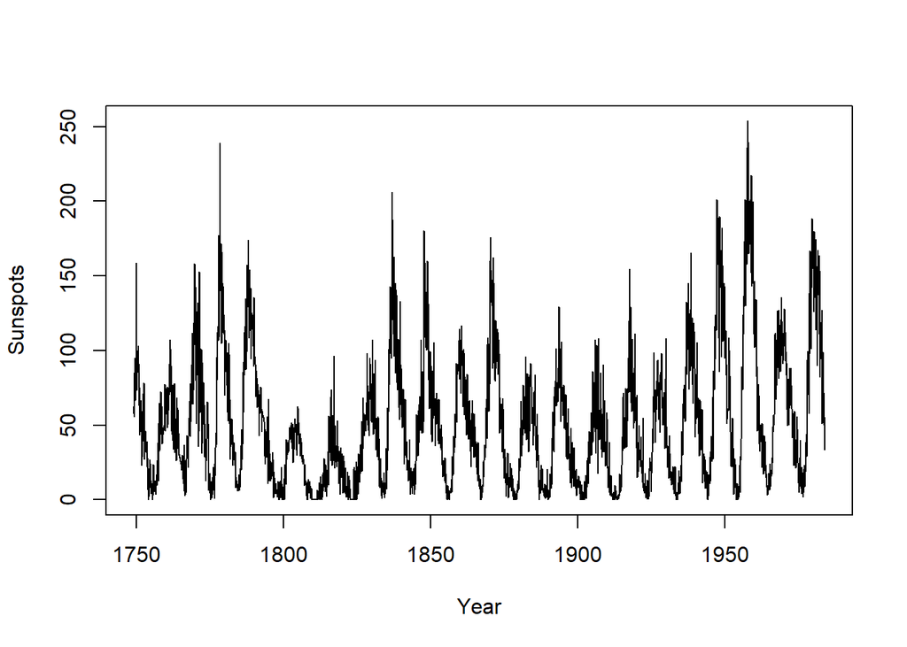

```r
wolfer <- read.table("wolfer.dat")
wolfer <- ts(wolfer,start=1749,frequency=12)
plot(wolfer,xlab="Year",ylab="Sunspots")
```

## Example: Unemployment Insurance Claims

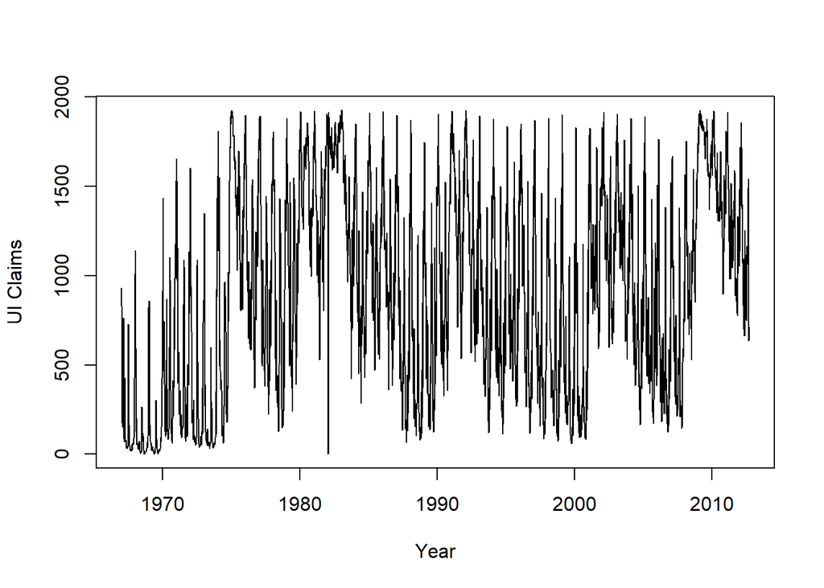

```r
ui <- read.table("ui.dat")
ui <- ts(ui,start=1967,frequency=52)
plot(ui,ylab="UI Claims",xlab="Year")
```

## Example: Mauna Loa carbon Dioxide

- Monthly measurements of CO2 levels on mount Mauna Loa.
- Apparent upward trend and monthly ($h=12$) cycle.

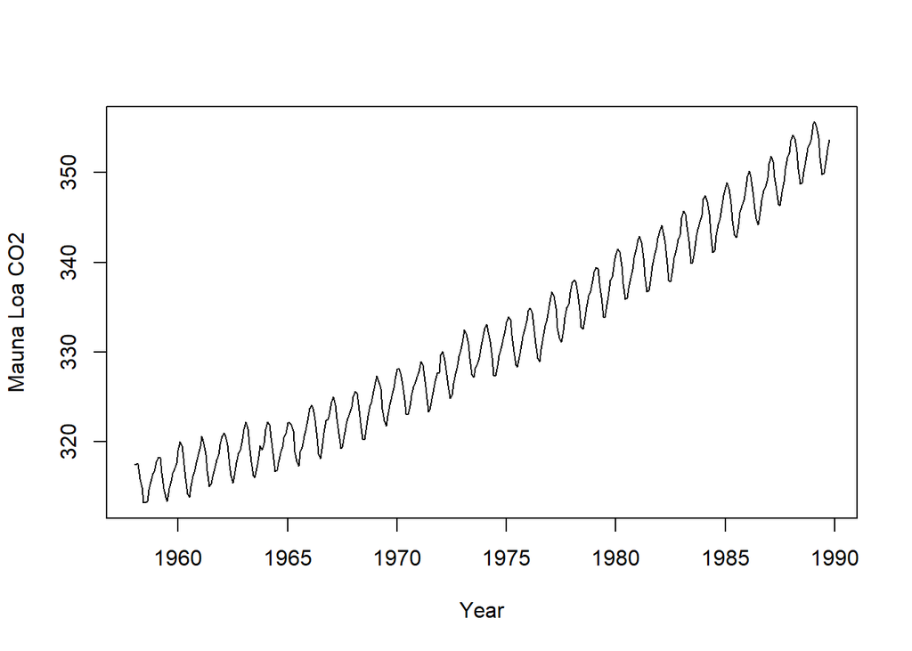

```r
mau <- read.table("mauna.dat",header=TRUE,sep="")
mau <- ts(mau,start=1958,frequency=12)
plot(mau,ylab="Mauna Loa CO2",xlab="Year")
```

## Example: Retail Sales of Motor Vehicles and Parts Dealers

- Monthly measurements of retail sales.
- Shows trend, monthly ($h=12$) cycle, and Great Recession.

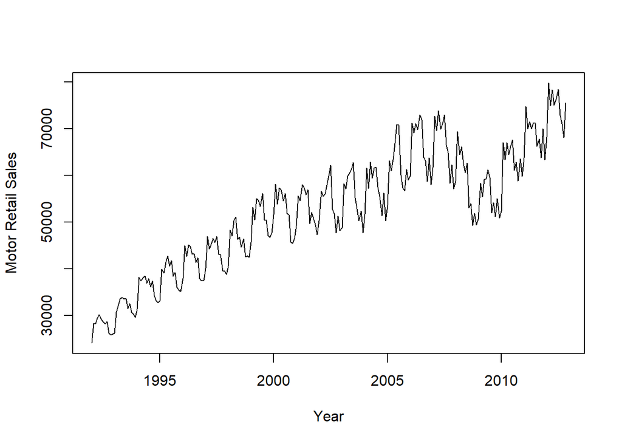

```r
Ret441 <- read.table("retail441.b1",header=TRUE,skip=2)[,2]
Ret441 <- ts(Ret441,start = 1992,frequency=12)
plot(Ret441, ylab="Motor Retail Sales",xlab="Year")
```

## Example: Housing Starts

- Monthly measurements of housing construction started (West Region).
- Shows trend, monthly ($h=12$) cycle, and some recessions/expansions.

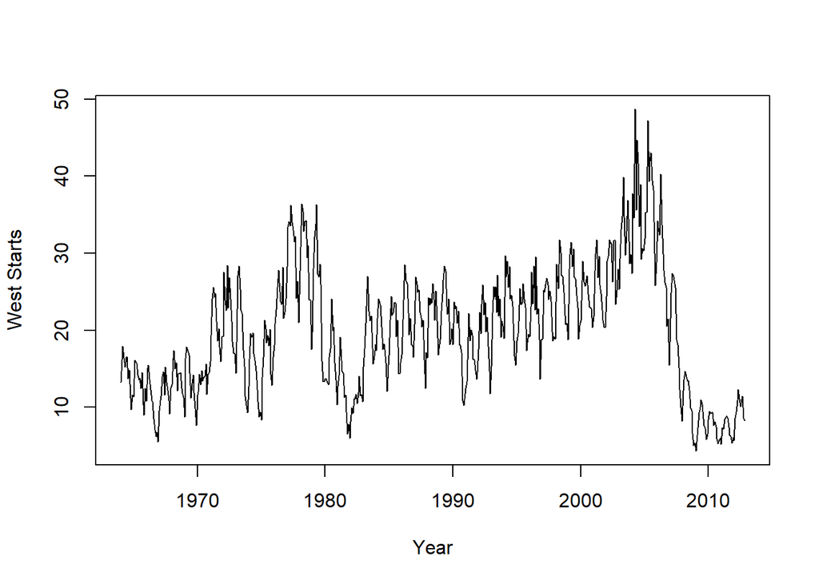

```r
Wstarts <- read.table("Wstarts.b1",header=TRUE,skip=2)[,2]
Wstarts <- ts(Wstarts,start = 1964,frequency=12)
plot(Wstarts, ylab="West Starts",xlab="Year")
```

## Log Transformation

- To visualize time series better, sometimes we apply a log transform (if the data is positive).
- If cycle amplitude depends on trend level, applying a log may separate this effect so that cycle amplitude is no longer growing.

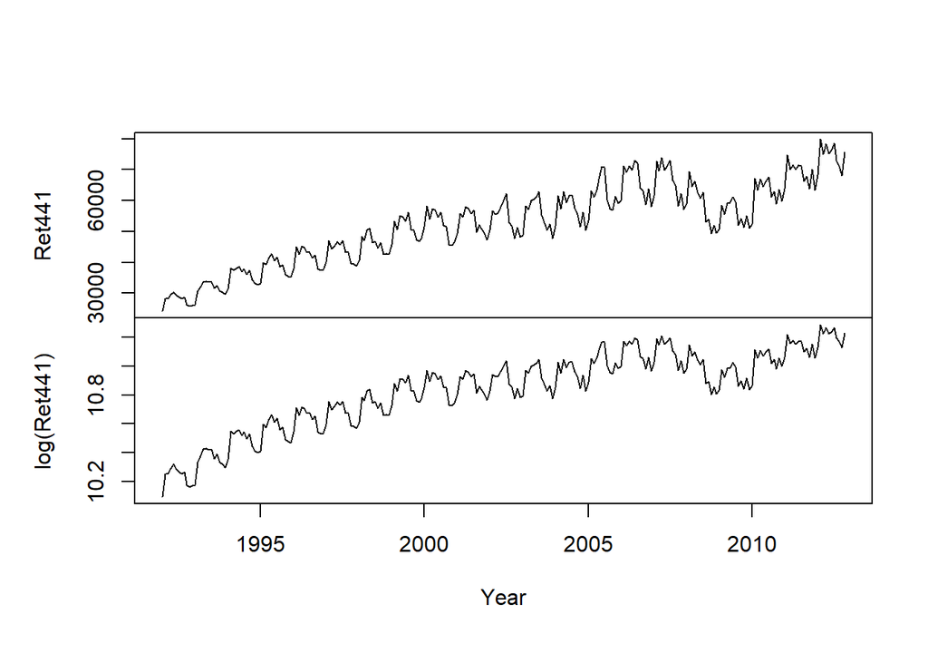

```r
Ret441_trans <- ts(cbind(Ret441,log(Ret441)),start = 1992,frequency=12)
plot(Ret441_trans, ylab="Motor Retail Sales",xlab="Year",main="")
```